# Equipo6_Datos_misteriosos

**Proyecto: Reto datos misteriosos**

**Facultad de Ciencias, UNAM**

**Asignatura: Técnicas experimentales**

**Profesores:**

Ana Karina Ramos Musalem

Ernesto Eduardo Gómez de la Peña

Iván Esau Arenas Ortíz

**Integrantes del equipo 6:**

Blas Ortega Alondra

Díaz Espinosa Kenya

Larson Rivero Lucía Kirene

**Fecha de entrega: 29/ 10/ 2020**

**1.- Campamento base.**

*Analizar el archivo para encontrar los metadatos.*

Nuestro archivo tiene 54 líneas de encabezado, y el valor nulo es 8989. Esto lo sabemos después de haber revisado el archivo en Excel.

Importamos **pandas** para leer el archivo

```python
import pandas as pd
```

```python
data = pd.read_csv('datos/archivo04.csv', header=54, na_values=8989)
```

Para ver el tipo de datos que tenemos usamos **data.dtypes**

```python
data.dtypes
```

```
Tiempo          object
Temperatura    float64
Bandera          int64
Cuenta           int64
dtype: object
```

**data.describe** nos da un resumen de la estadística del conjunto de datos

```python
data.describe()
```

|  | Temperatura | Bandera | Cuenta |
| --- | --- | --- | --- |
| count | 7048.000000 | 8760.000000 | 8760.000000 |
| mean | -12.607884 | 7.081621 | 49.551370 |
| std | 15.144570 | 0.682554 | 20.411776 |
| min | -40.496792 | 6.000000 | 0.000000 |
| 25% | -25.870165 | 7.000000 | 55.000000 |
| 50% | -12.882536 | 7.000000 | 60.000000 |
| 75% | 0.986746 | 7.000000 | 60.000000 |
| max | 17.698325 | 9.000000 | 61.000000 |

Pedimos que imprima data

```python
print(data)
```

```
                   Tiempo  Temperatura  Bandera  Cuenta
0     2019-01-01 00:30:00   -25.102567        7      60
1     2019-01-01 01:30:00   -24.406491        7      60
2     2019-01-01 02:30:00   -24.214873        7      60
3     2019-01-01 03:30:00   -24.700724        7      52
4     2019-01-01 04:30:00   -25.655208        7      60
...                   ...          ...      ...     ...
8755  2019-12-31 19:30:00   -28.990197        7      60
8756  2019-12-31 20:30:00   -29.290185        7      60
8757  2019-12-31 21:30:00   -29.437079        7      60
8758  2019-12-31 22:30:00   -29.393909        7      60
8759  2019-12-31 23:30:00   -29.631943        7      60

[8760 rows x 4 columns]
```

Debido la gran cantidad de datos es más práctico visualizarlos por secciones. Visualisamos las primeras 10 y las últimas 10 líneas de datos con **data.head** y **data.tail**

```python
data.head(10)
```

|  | Tiempo | Temperatura | Bandera | Cuenta |
| --- | --- | --- | --- | --- |
| 0 | 2019-01-01 00:30:00 | -25.102567 | 7 | 60 |
| 1 | 2019-01-01 01:30:00 | -24.406491 | 7 | 60 |
| 2 | 2019-01-01 02:30:00 | -24.214873 | 7 | 60 |
| 3 | 2019-01-01 03:30:00 | -24.700724 | 7 | 52 |
| 4 | 2019-01-01 04:30:00 | -25.655208 | 7 | 60 |
| 5 | 2019-01-01 05:30:00 | -26.124568 | 7 | 60 |
| 6 | 2019-01-01 06:30:00 | -25.914960 | 7 | 60 |
| 7 | 2019-01-01 07:30:00 | -25.874440 | 7 | 60 |
| 8 | 2019-01-01 08:30:00 | -25.935127 | 7 | 60 |
| 9 | 2019-01-01 09:30:00 | -25.739856 | 7 | 60 |

```python
data.tail(10)
```

|  | Tiempo | Temperatura | Bandera | Cuenta |
| --- | --- | --- | --- | --- |
| 8750 | 2019-12-31 14:30:00 | -27.888567 | 7 | 60 |
| 8751 | 2019-12-31 15:30:00 | -28.119507 | 7 | 60 |
| 8752 | 2019-12-31 16:30:00 | -27.906883 | 7 | 60 |
| 8753 | 2019-12-31 17:30:00 | -27.964474 | 7 | 60 |
| 8754 | 2019-12-31 18:30:00 | -28.614777 | 7 | 47 |
| 8755 | 2019-12-31 19:30:00 | -28.990197 | 7 | 60 |
| 8756 | 2019-12-31 20:30:00 | -29.290185 | 7 | 60 |
| 8757 | 2019-12-31 21:30:00 | -29.437079 | 7 | 60 |
| 8758 | 2019-12-31 22:30:00 | -29.393909 | 7 | 60 |
| 8759 | 2019-12-31 23:30:00 | -29.631943 | 7 | 60 |

Con esta información y la encontrada en el encabezado respondemos:

**a)** ¿Qué información hay en el archivo a simple vista?

R:

- Fuente de donde se obtuvieron los datos: "Ocean Networks Canada Data Archive".
- Institución que realizó las mediciones: University of Victoria.
- Ubicación del lugar en donde se midieron los datos
- Latitud:69.114233 Norte
- Longitud:-105.058967 Este
- Profundidad: 0.0 (m).
- Valores de temperatura.
- Fecha y hora en la que fueron tomadas las mediciones.
- Banderas, las cuales nos indican la calidad de la medición.
- Periodo de mediciones: Del 2019-01-01 00:00:00.000 al 2020-01-01 00:00:00.000.

**b)** ¿Qué unidades de medición se reportan?

R:

- Temperatura del aire en superficie: Temperatura en grados centígrados (°C).
- Bandera: Es una variable estadística de tipo cualitativo ordinal.

**c)** ¿Estas unidades corresponden al Sistema Internacional de Unidades? Si no es así, ¿cuáles son las unidades equivalentes en el SI?

R: No, porque la unidad básica en el SI para la temperatura es el Kelvin: La fórmula para convertir grados centígrados a kelvin es °C +273.15=K. Por otro lado, la bandera es la que presenta estados y se ocupa en programación, por lo tanto, sus unidades no corresponden al SI.

**2. Sumidero de la incertidumbre.**

*Graficar los datos*

Importamos **matplotlib** para graficar

```
<bound method Figure.autofmt_xdate of <Figure size 2160x1800 with 1 Axes>>
```

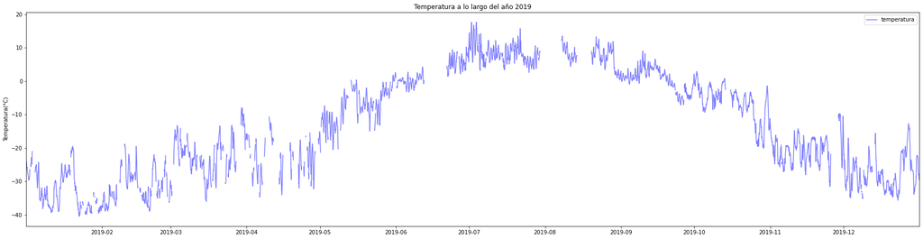

```python
import pandas as pd
import matplotlib.pyplot as plt

data=pd.read_csv("datos/archivo04.csv",header=54,na_values=8989)

fig=plt.figure(figsize=(30,25))
ax = fig.add_subplot(3,1,1)
fechas_datetime=pd.to_datetime(data["Tiempo"])
ax.plot(fechas_datetime,data["Temperatura"],color="b",alpha=0.5, label="temperatura")

ax.set_ylabel("Temperatura(°C)")
ax.set_title("Temperatura a lo largo del año 2019")
ax.set_xlim(fechas_datetime[0], fechas_datetime[8759])
ax.legend()
fig.autofmt_xdate
```

Ahora graficaremos los datos por tres periodos de tiempo: Los meses fríos de enero a mayo, que corresponden a la primera parte del invierno del año, los meses cálidos de junio a septiembre que son los correpondientes al "verano", y los meses fríos de octubre a diciembre, que son la segunda parte del invierno. Escogimos estos intervalos tomando en cuenta que en el punto geográfico donde se tomaron las mediciones (Canadá) en los meses de verano las temperaturas van entre los 0 ºC a 10ºC,y en los meses de invierno son menores a 0ºC hasta los -50°C.

Encontramos la fila donde termina el mes requerido dividiendo el número total de datos(obteniendo el número de datos por mes) y multiplicando este resultado por el número del mes buscado. Dado que no tenemos la certeza de que todos los meses abarquen exactamente el mismo número de datos, el resultado será un aproximado

Por último, se gráfico un día representativo de cada estación (invierno y verano). Para tratar de identificar, si existía alguna oscilación ciclíca durante el día. A partir de las gráficas, no es observable ningún ciclo, esto es probable ya que la incidencia de la luz solar en las zonas polares, en invierno no es constante o casí nula, y en verano es casí constante durante todo el día.

```python
8760/12
```

```
730.0
```

Dado que el primer dato se encuentra en la fila 0, no 1, enero termina en la fila 729, y cada mes abarca 730 filas.

```python
print('mayo termina aproximadamente en la fila', 729+(730*4))
print('septiembre termina aproximadamente en la fila', 729+(730*8))
print('diciembre termina en la fila', 729+(730*11))
```

```
mayo termina aproximadamente en la fila 3649
septiembre termina aproximadamente en la fila 6569
diciembre termina en la fila 8759
```

Con esto podemos definir aproximadamente el inicio y fin de nuestros meses,para encontrar la frontera exacta buscamos directamente en el archivo, teniendo como referencia los valores obtenidos anteriormente para agilizar la búsqueda

```
Graficamos desde 2019-01-01 00:30:00 hasta 2019-05-31 23:30:00
```

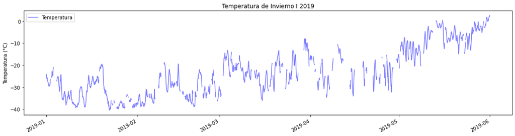

```python
print("Graficamos desde",data["Tiempo"][0],"hasta",data["Tiempo"][3623])

fig = plt.figure(figsize=(18,15))
ax = fig.add_subplot(3,1,1)
ax.plot(pd.to_datetime(data['Tiempo'][0:3623]),data['Temperatura'][0:3623], color='blue',
        alpha=0.5, label='Temperatura')
ax.set_ylabel('Temperatura (°C)')
ax.set_title('Temperatura de Invierno I 2019')
ax.legend()
fig.autofmt_xdate()
```

Obtenemos el resumen estadístico de los primeros meses fríos

```python
data[0:3623].describe()
```

|  | Temperatura | Bandera | Cuenta |
| --- | --- | --- | --- |
| count | 2717.000000 | 3623.000000 | 3623.000000 |
| mean | -22.925506 | 6.821143 | 48.565001 |
| std | 11.055858 | 0.537932 | 19.732896 |
| min | -40.496792 | 6.000000 | 0.000000 |
| 25% | -31.957431 | 7.000000 | 41.500000 |
| 50% | -24.666533 | 7.000000 | 60.000000 |
| 75% | -14.578719 | 7.000000 | 60.000000 |
| max | 2.583652 | 9.000000 | 61.000000 |

```
Graficamos desde 2019-06-01 00:30:00 hasta 2019-09-30 23:30:00
```

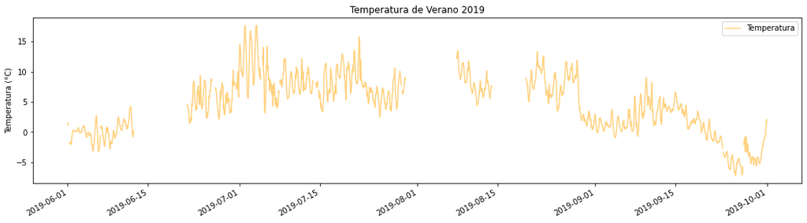

```python
print("Graficamos desde",data["Tiempo"][3624],"hasta",data["Tiempo"][6551])

fig = plt.figure(figsize=(18,15))
ax = fig.add_subplot(3,1,1)
ax.plot(pd.to_datetime(data['Tiempo'][3624:6551]),data['Temperatura'][3624:6551], color='orange',
        alpha=0.5, label='Temperatura')
ax.set_ylabel('Temperatura (°C)')
ax.set_title('Temperatura de Verano 2019')
ax.legend()
fig.autofmt_xdate()
```

Obtenemos el resumen estadístico de los meses cálidos

```python
data[3624:6551].describe()
```

|  | Temperatura | Bandera | Cuenta |
| --- | --- | --- | --- |
| count | 2295.000000 | 2927.000000 | 2927.000000 |
| mean | 4.550105 | 7.373420 | 47.307824 |
| std | 4.659397 | 0.816117 | 23.893001 |
| min | -7.190637 | 6.000000 | 0.000000 |
| 25% | 1.016876 | 7.000000 | 58.000000 |
| 50% | 4.814946 | 7.000000 | 60.000000 |
| 75% | 8.005744 | 7.000000 | 60.000000 |
| max | 17.698325 | 9.000000 | 61.000000 |

```
Graficamos desde 2019-10-01 00:30:00 hasta 2019-12-31 23:30:00
```

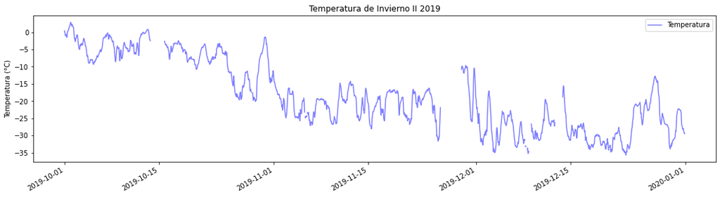

```python
print("Graficamos desde",data["Tiempo"][6552],"hasta",data["Tiempo"][8759])

fig = plt.figure(figsize=(18,15))
ax = fig.add_subplot(3,1,1)
ax.plot(pd.to_datetime(data['Tiempo'][6552:8759]),data['Temperatura'][6552:8759], color='blue',
        alpha=0.5, label='Temperatura')
ax.set_ylabel('Temperatura (°C)')
ax.set_title('Temperatura de Invierno II 2019')
ax.legend()
fig.autofmt_xdate()
```

Obtenemos el resumen estadístico de los últimos meses fríos

```python
data[6552:8759].describe()
```

|  | Temperatura | Bandera | Cuenta |
| --- | --- | --- | --- |
| count | 2033.000000 | 2207.000000 | 2207.000000 |
| mean | -18.193737 | 7.122338 | 54.131853 |
| std | 10.056412 | 0.514948 | 15.110992 |
| min | -35.688809 | 6.000000 | 0.000000 |
| 25% | -26.239280 | 7.000000 | 56.000000 |
| 50% | -19.600375 | 7.000000 | 60.000000 |
| 75% | -8.167658 | 7.000000 | 60.000000 |
| max | 2.896773 | 9.000000 | 60.000000 |

Para observar aún más a detalle los datos, graficaremos los datos de 24 horas de un día en los meses cálidos, y de un día en los meses fríos, y obtendremos sus respectivos resúmenes estadísticos.

```
Graficamos desde 2019-01-01 00:30:00 hasta 2019-01-01 23:30:00
```

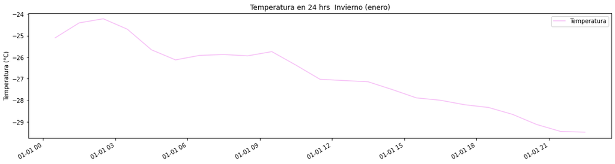

```python
print("Graficamos desde",data["Tiempo"][0],"hasta",data["Tiempo"][23])

fig = plt.figure(figsize=(18,15))
ax = fig.add_subplot(3,1,1)
ax.plot(pd.to_datetime(data['Tiempo'][0:23]),data['Temperatura'][0:23], color='violet',
        alpha=0.5, label='Temperatura')
ax.set_ylabel('Temperatura (°C)')
ax.set_title('Temperatura en 24 hrs  Invierno (enero)')
ax.legend()
fig.autofmt_xdate()
```

```python
data[0:23].describe()
```

|  | Temperatura | Bandera | Cuenta |
| --- | --- | --- | --- |
| count | 23.000000 | 23.0 | 23.000000 |
| mean | -26.865261 | 7.0 | 59.652174 |
| std | 1.591687 | 0.0 | 1.668115 |
| min | -29.476618 | 7.0 | 52.000000 |
| 25% | -28.099950 | 7.0 | 60.000000 |
| 50% | -27.024106 | 7.0 | 60.000000 |
| 75% | -25.807148 | 7.0 | 60.000000 |
| max | -24.214873 | 7.0 | 60.000000 |

```
Graficamos desde 2019-07-01 00:30:00 hasta 2019-07-01 23:30:00
```

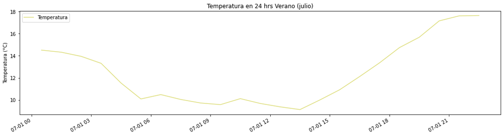

```python
print("Graficamos desde",data["Tiempo"][4344],"hasta",data["Tiempo"][4367])

fig = plt.figure(figsize=(18,15))
ax = fig.add_subplot(3,1,1)
ax.plot(pd.to_datetime(data['Tiempo'][4344:4367]),data['Temperatura'][4344:4367], color='y',
        alpha=0.5, label='Temperatura')
ax.set_ylabel('Temperatura (°C)')
ax.set_title('Temperatura en 24 hrs Verano (julio)')
ax.legend()
fig.autofmt_xdate()
```

```python
data[4344:4367].describe()
```

|  | Temperatura | Bandera | Cuenta |
| --- | --- | --- | --- |
| count | 23.000000 | 23.0 | 23.0 |
| mean | 12.394339 | 7.0 | 60.0 |
| std | 2.837681 | 0.0 | 0.0 |
| min | 9.122886 | 7.0 | 60.0 |
| 25% | 10.018096 | 7.0 | 60.0 |
| 50% | 11.529581 | 7.0 | 60.0 |
| 75% | 14.418641 | 7.0 | 60.0 |
| max | 17.648461 | 7.0 | 60.0 |

# Ascenso a la cima

## Análisis de datos y gráficas

[figure not shown]

¿Pueden pensar en algún fenómeno físico que se explique a partir de estos datos? R: La medición de los datos, representan las características climatológicas y meteorológicas de la zona. También, este tipo de mediciones de la oscilación de la temperatura del aire durante años, son utilizados como registro, para evaluar el cambio climático, y de igual forma como evidencia del calentamiento global.

¿Con qué instrumentos fueron realizadas estas mediciones? ¿Cómo funciona este aparato? R: Las mediciones fueron realizadas con Lufft WS501.Este es un sensor meteorológico compacto que mide temperatura del aire, humedad relativa, dirección y velocidad del viento y radiación. La tecnología que usa para efectuar las mediciones, son las siguientes: Ultrasónico / Viento, NTC / T, Capacitivo / RH, MEMS capacitivo / Presión, Kipp & Zonen Piranómetro / Radiación. Un sensor meteorológico, atendiendo a la definición de la Agencia Estatal de Meteorología (AEMET) (1), es un «dispositivo diseñado para recibir información de una magnitud meteorológica y transformarla en otra, en muchos casos eléctrica, que se pueda cuantificar y procesar» para facilitar su comprensión.

[figure not shown]

#### Fotografía: Sensor meteorológico inteligente WS501-UMB

#### Referencias:

-Gabler, R., Petersen, J. y Trapasso, L. (2007). Fundamentos de la geografía física . Belmont, CA: Thomson Brooks / Cole.

-WS501-UMB Smart Weather Sensor. (s. f.). Lufft. Recuperado 29 de octubre de 2020, de https://www.lufft.com/products/compact-weather-sensors-293/ws501-umb-smart-weather-sensor-1839/

-Cambridge Bay Community Observatory Backgrounder (2012). En Ocean Networks Canada. Recuperado de https://www.oceannetworks.ca/cambridge-bay-community-observatory-backgrounder (octubre, 2020).

-Enviraiot. Qué son y para qué sirven los sensores meteorológicos. Recuperado 29 de octubre del 2020, de https://enviraiot.es/que-son-sensores-meteorologicos/#:~:text=Un%20sensor%20meteorol%C3%B3gico%2C%20atendiendo%20a,procesar%C2%BB%20para%20facilitar%20su%20comprensi%C3%B3n.